# Linear regression: testing and diagnostics

Bikramjit Das

2025

We will attach install/load packages as and when needed.

# 1 Auto dataset

## 1.1 Simple linear regression

This data set is available in the `StatLib` library maintained at Carnegie Mellon University. The data set has the following fields:

- `mpg`: miles per gallon
- `cylinders`: number of cylinders
- `displacement`: engine displacement (cu. inches)
- `horsepower`: engine horsepower
- `acceleration`: time to accelerate from 0 to 60 mph (sec.)
- `year`: model year (modulo 100)
- `origin`: origin of car (1. American, 2. European, 3. Japanese)
- `name`: vehicle name

We want to find a relationship between `mpg` (response) and the other variables `horsepower`. First we read the data.

```r
auto<-read.csv("Auto.csv")
str(auto)
```

```
## 'data.frame':    397 obs. of  9 variables:
##  $ mpg         : num  18 15 18 16 17 15 14 14 14 15 ...
##  $ cylinders   : int  8 8 8 8 8 8 8 8 8 8 ...
##  $ displacement: num  307 350 318 304 302 429 454 440 455 390 ...
##  $ horsepower  : chr  "130" "165" "150" "150" ...
##  $ weight      : int  3504 3693 3436 3433 3449 4341 4354 4312 4425 3850 ...
##  $ acceleration: num  12 11.5 11 12 10.5 10 9 8.5 10 8.5 ...
##  $ year        : int  70 70 70 70 70 70 70 70 70 70 ...
##  $ origin      : int  1 1 1 1 1 1 1 1 1 1 ...
##  $ name        : chr  "chevrolet chevelle malibu" "buick skylark 320" "plymouth satellite" "amc rebel sst" ...
```

Observe that the variable `horsepower` is a *character* variable, so we convert it to *numeric*.

```r
auto$horsepower <- as.numeric(as.character(auto$horsepower))
```

Now fit a simple linear regression model between `mpg` and `horsepower`.

```r
model1<- lm(mpg~horsepower, data=auto)
summary(model1)
```

```
##
## Call:
## lm(formula = mpg ~ horsepower, data = auto)
##
## Residuals:
##      Min       1Q   Median       3Q      Max
## -13.5710  -3.2592  -0.3435   2.7630  16.9240
##
## Coefficients:
##              Estimate Std. Error t value Pr(>|t|)
## (Intercept) 39.935861   0.717499   55.66   <2e-16 ***
## horsepower  -0.157845   0.006446  -24.49   <2e-16 ***
## ---
## Signif. codes:  0 '***' 0.001 '**' 0.01 '*' 0.05 '.' 0.1 ' ' 1
##
## Residual standard error: 4.906 on 390 degrees of freedom
##   (5 observations deleted due to missingness)
## Multiple R-squared:  0.6059, Adjusted R-squared:  0.6049
## F-statistic: 599.7 on 1 and 390 DF,  p-value: < 2.2e-16
```

- There seems to be a strong relationship between the predictor and response.
- The p-value is almost zero, implying we can reject the null hypothesis that the corresponding $\beta_1= 0$.
- Since $\widehat{\beta}_1=-0.1578$, there is a negative linear relationship between mpg and horsepower.

Now, let’s do some prediction. What is the predicted `mpg` associated with a `horsepower` of 98?

```r
predict.lm(model1,newdata=data.frame(horsepower=98))
```

```
##        1
## 24.46708
```

What is the associated 95% **confidence interval**?

```r
p1<-predict.lm(model1,newdata=data.frame(horsepower=98),interval=c("confidence"),level=.95)
p1
```

```
##        fit      lwr      upr
## 1 24.46708 23.97308 24.96108
```

What is the associated 95% **prediction interval**?

```r
p2<-predict.lm(model1,newdata=data.frame(horsepower=98),interval=c("prediction"),level=.95)
p2
```

```
##        fit     lwr      upr
## 1 24.46708 14.8094 34.12476
```

- The predicted `mpg` for `horsepower` of 98 is 24.467.
- 95% confidence interval is [23.973, 24.961].
- 95% prediction interval is [14.809, 34.125].

Next we find correlation between the response and the predictor variable.

We use `cor(auto$mpg,auto$horsepower, use = "pairwise.complete.obs")` which excludes entries whenever one of the entries is `NA`.

```r
cor(auto$mpg,auto$horsepower, use = "pairwise.complete.obs")
```

```
## [1] -0.7784268
```

```r
cor(auto$mpg,auto$horsepower, use = "pairwise.complete.obs")^2
```

```
## [1] 0.6059483
```

- Here $R^2=0.6059$ which is just square of the correlation computed.

Now let’s plot the response against the predictor.

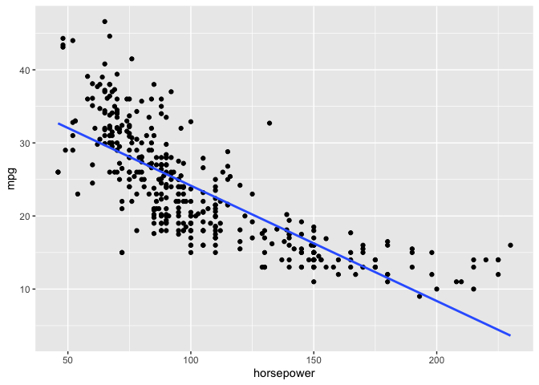

```r
#install.packages(ggplot2)
library(ggplot2)
ggplot(auto,aes(horsepower,mpg))+geom_point(na.rm=T)+geom_smooth(method="lm",na.rm=T,se=F)
```

```r
# Alternative plotting
#plot(auto$horsepower,auto$mpg)
#abline(model1)
```

- We also plot the least squares regression line, it tends to indicate that there are some non-linearities. To check this we need to do a `residual plot`.
- Install the package `ggfortify` which aids plotting linear models with `ggplot2`. We then do some `residual plots` and `Normal Q-Q plot` for diagnostics.

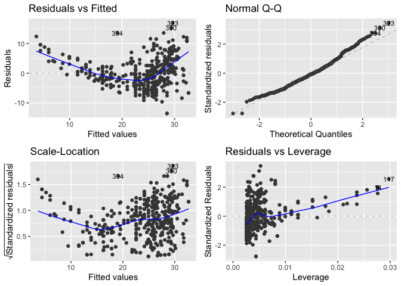

```r
#install.packages(ggfortify)
library(ggfortify)
autoplot(model1,label.size = 3)
```

```r
# Alternative plotting without ggplot
#layout(matrix(1:4,2,2))
#plot(model1)
```

- A good linear fit should have the residuals randomly scattered. In this model we see that the residuals decrease, and then increase as the number of fitted residuals increase.
- The normal QQ plot also shows that the distribution of the residuals is not normal at the extreme tails. This indicates that the data might have evidence of some non-linearities and outliers.
- Now let us add a non-linear component `horsepower`$^2$ and regress `mpg` on both `horsepower` and `horsepower`$^2$.

```r
auton<-auto
auton$horse2<-auton$horsepower^2
model2<- lm(mpg~horsepower+horse2, data=auton)
summary(model2)
```

```
##
## Call:
## lm(formula = mpg ~ horsepower + horse2, data = auton)
##
## Residuals:
##      Min       1Q   Median       3Q      Max
## -14.7135  -2.5943  -0.0859   2.2868  15.8961
##
## Coefficients:
##               Estimate Std. Error t value Pr(>|t|)
## (Intercept) 56.9000997  1.8004268   31.60   <2e-16 ***
## horsepower  -0.4661896  0.0311246  -14.98   <2e-16 ***
## horse2       0.0012305  0.0001221   10.08   <2e-16 ***
## ---
## Signif. codes:  0 '***' 0.001 '**' 0.01 '*' 0.05 '.' 0.1 ' ' 1
##
## Residual standard error: 4.374 on 389 degrees of freedom
##   (5 observations deleted due to missingness)
## Multiple R-squared:  0.6876, Adjusted R-squared:  0.686
## F-statistic:   428 on 2 and 389 DF,  p-value: < 2.2e-16
```

- The fit seems reasonable with a higher multiple-$R^2 =0.688$. Let’s look at the residual plot and compare with the previous model

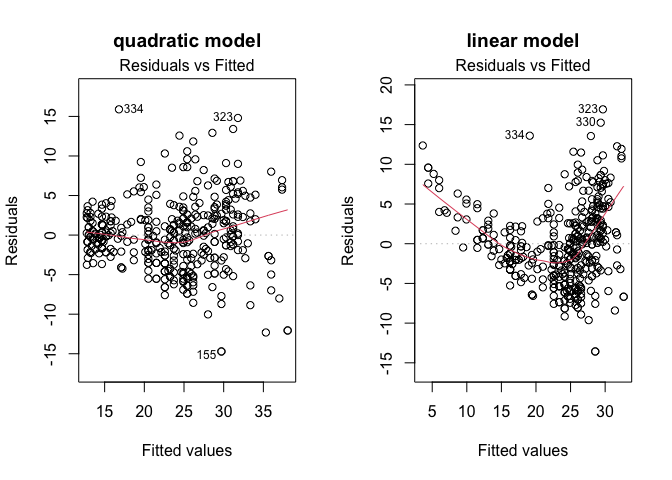

```r
par(mfrow=c(1,2))
plot(model2,which=1,main="quadratic model")
plot(model1,which=1, main= "linear model")
```

- Here the residual also indicate that a quadratic relationship between `mpg` and `horsepower` is more plausible.

## 1.2 Multiple linear regression

Now we use the same data for multiple linear regression. First we create a scatterplot matrix which includes all the variables in the dataset.

An easy way to do this is using `pairs(your_data_name)`. Instead we use the package `psych` and `pairs.panel`.

```r
library(psych)
```

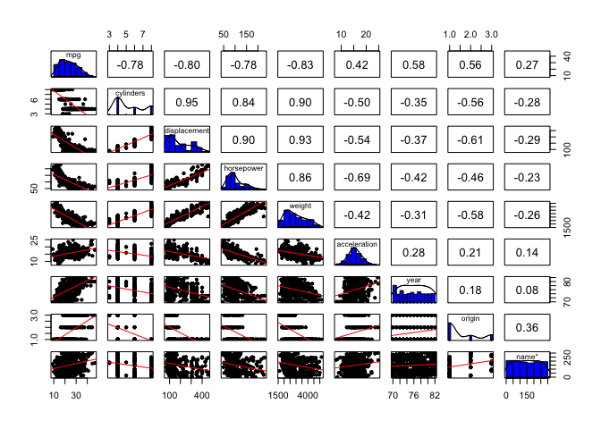

```r
pairs.panels(auto,ellipses = F, lm =T, breaks=10, hist.col="blue")
```

We can also compute a matrix of correlations between the variables using the function `cor()`. You need to exclude the `name` variable which is qualitative. Also we remove the entries where we had `NA` appearing. The code is given below.

```r
str(auto)
```

```
## 'data.frame':    397 obs. of  9 variables:
##  $ mpg         : num  18 15 18 16 17 15 14 14 14 15 ...
##  $ cylinders   : int  8 8 8 8 8 8 8 8 8 8 ...
##  $ displacement: num  307 350 318 304 302 429 454 440 455 390 ...
##  $ horsepower  : num  130 165 150 150 140 198 220 215 225 190 ...
##  $ weight      : int  3504 3693 3436 3433 3449 4341 4354 4312 4425 3850 ...
##  $ acceleration: num  12 11.5 11 12 10.5 10 9 8.5 10 8.5 ...
##  $ year        : int  70 70 70 70 70 70 70 70 70 70 ...
##  $ origin      : int  1 1 1 1 1 1 1 1 1 1 ...
##  $ name        : chr  "chevrolet chevelle malibu" "buick skylark 320" "plymouth satellite" "amc rebel sst" ...
```

```r
autored<-subset(auto,select=-c(name))
#str(autored)
#cor(autored)
cor(autored, use = "complete") ## presence of NA in horsepower values renders this correlation NA, so we need to add "complete"
```

```
##                     mpg  cylinders displacement horsepower     weight
## mpg           1.0000000 -0.7776175   -0.8051269 -0.7784268 -0.8322442
## cylinders    -0.7776175  1.0000000    0.9508233  0.8429834  0.8975273
## displacement -0.8051269  0.9508233    1.0000000  0.8972570  0.9329944
## horsepower   -0.7784268  0.8429834    0.8972570  1.0000000  0.8645377
## weight       -0.8322442  0.8975273    0.9329944  0.8645377  1.0000000
## acceleration  0.4233285 -0.5046834   -0.5438005 -0.6891955 -0.4168392
## year          0.5805410 -0.3456474   -0.3698552 -0.4163615 -0.3091199
## origin        0.5652088 -0.5689316   -0.6145351 -0.4551715 -0.5850054
##              acceleration       year     origin
## mpg             0.4233285  0.5805410  0.5652088
## cylinders      -0.5046834 -0.3456474 -0.5689316
## displacement   -0.5438005 -0.3698552 -0.6145351
## horsepower     -0.6891955 -0.4163615 -0.4551715
## weight         -0.4168392 -0.3091199 -0.5850054
## acceleration    1.0000000  0.2903161  0.2127458
## year            0.2903161  1.0000000  0.1815277
## origin          0.2127458  0.1815277  1.0000000
```

```r
sum(is.na(autored))
```

```
## [1] 5
```

```r
auto1<-subset(autored,!is.na(autored$horsepower))
dim(autored)
```

```
## [1] 397   8
```

```r
dim(auto1)
```

```
## [1] 392   8
```

Now we perform a multiple linear regression with `mpg` as the response and all other variables except `name` as the predictors.

```r
model3 <-lm(mpg~., data=auto1)
summary(model3)
```

```
##
## Call:
## lm(formula = mpg ~ ., data = auto1)
##
## Residuals:
##     Min      1Q  Median      3Q     Max
## -9.5903 -2.1565 -0.1169  1.8690 13.0604
##
## Coefficients:
##                Estimate Std. Error t value Pr(>|t|)
## (Intercept)  -17.218435   4.644294  -3.707  0.00024 ***
## cylinders     -0.493376   0.323282  -1.526  0.12780
## displacement   0.019896   0.007515   2.647  0.00844 **
## horsepower    -0.016951   0.013787  -1.230  0.21963
## weight        -0.006474   0.000652  -9.929  < 2e-16 ***
## acceleration   0.080576   0.098845   0.815  0.41548
## year           0.750773   0.050973  14.729  < 2e-16 ***
## origin         1.426141   0.278136   5.127 4.67e-07 ***
## ---
## Signif. codes:  0 '***' 0.001 '**' 0.01 '*' 0.05 '.' 0.1 ' ' 1
##
## Residual standard error: 3.328 on 384 degrees of freedom
## Multiple R-squared:  0.8215, Adjusted R-squared:  0.8182
## F-statistic: 252.4 on 7 and 384 DF,  p-value: < 2.2e-16
```

- The p-value for the multiple regression model is very close to 0. Hence we can reject the null hypotheses that all the $\beta_i$’s are zero; so there seems to be a strong linear relationship between the predictors and the response.
- The variables `displacement`, `weight`, `year` and `origin` are statistically significant at a 1% level.
- For example, the coefficient for `year` is positive and the p-value is close to 0. This shows that `year` is positively related to `mpg` where every year adds 0.7508 miles per gallon, everything else staying the same. It also shows newer cars have better performance on an average.
- In the full model we find `cylinder`, `horsepower` and `acceleration` to be not significant individually. We can test if all of them are indeed not significant (jointly). We create a new model without these variables and conduct an appropriate F-test.

```r
model3var<-lm(mpg~displacement+weight+year+origin, data=auto1)
summary(model3var)
```

```
##
## Call:
## lm(formula = mpg ~ displacement + weight + year + origin, data = auto1)
##
## Residuals:
##     Min      1Q  Median      3Q     Max
## -9.8102 -2.1129 -0.0388  1.7725 13.2085
##
## Coefficients:
##                Estimate Std. Error t value Pr(>|t|)
## (Intercept)  -1.861e+01  4.028e+00  -4.620 5.25e-06 ***
## displacement  5.588e-03  4.768e-03   1.172    0.242
## weight       -6.575e-03  5.571e-04 -11.802  < 2e-16 ***
## year          7.714e-01  4.981e-02  15.486  < 2e-16 ***
## origin        1.226e+00  2.670e-01   4.593 5.92e-06 ***
## ---
## Signif. codes:  0 '***' 0.001 '**' 0.01 '*' 0.05 '.' 0.1 ' ' 1
##
## Residual standard error: 3.346 on 387 degrees of freedom
## Multiple R-squared:  0.8181, Adjusted R-squared:  0.8162
## F-statistic: 435.1 on 4 and 387 DF,  p-value: < 2.2e-16
```

- Can we really say tha the other variables are not significant at all?

```r
SSE<-sum(model3$residuals^2)
SSEnew<-sum(model3var$residuals^2)

n<-dim(auto1)[1]
p<-dim(auto1)[2]-1
q<-3
Fnew<-((SSEnew-SSE)/q)/(SSE/(n-p-1)) ## SSR-SSRnew = (SST-SSE)-(SST-SSEnew)= SSEnew-SSE

Fnew
```

```
## [1] 2.423696
```

```r
pval<-pf(Fnew,3,384,lower.tail = F)
pval
```

```
## [1] 0.06542561
```

Since the p-value is not less than 0.05 we cannot really reject the hypothesis that all of the coefficients of `cylinder`, `horsepower` and `acceleration` are indeed 0.

# 2 Multicollinearity

Here we use a simulated data set. First we generate the data using the following commands in R:

```r
set.seed(1)
x1 <- runif(100)
x2 <- 0.5*x1 + rnorm(100)/10
y <- 2 + 2*x1 + 0.3*x2 + rnorm(100)
```

- The last line corresponds to creating a linear model in which `y` is a function of `x1` and `x2`.
- The form of the linear model is:
  $$y
  = \beta_0+ \beta_1 x_1 + \beta_2 x_2 +\epsilon$$
  where the coefficients are $\beta_0=2, \beta_1=2, \beta_2=0.3$.

Let us find the correlation between `x1` and `x2` first and create a scatterplot displaying the relationship between the variables.

```r
cor(x1,x2)
```

```
## [1] 0.8351212
```

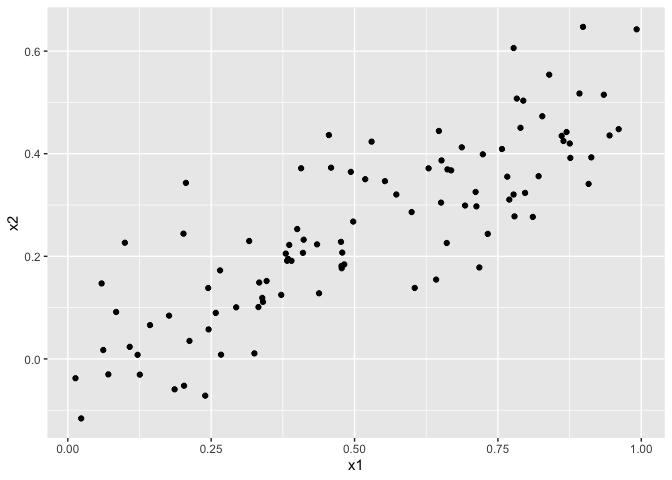

```r
ggplot(cbind(x1,x2,y),aes(x1,x2))+geom_point()
```

- The correlation is 0.8351. This clearly shows a strong positive correlation between `x1` and `x2` (as also seen in the scatterplot).

Now let us fit a least square regression to predict `y` using `x1` and `x2`.

```r
model4 <- lm(y~x1+x2)
summary(model4)
```

```
##
## Call:
## lm(formula = y ~ x1 + x2)
##
## Residuals:
##     Min      1Q  Median      3Q     Max
## -2.8311 -0.7273 -0.0537  0.6338  2.3359
##
## Coefficients:
##             Estimate Std. Error t value Pr(>|t|)
## (Intercept)   2.1305     0.2319   9.188 7.61e-15 ***
## x1            1.4396     0.7212   1.996   0.0487 *
## x2            1.0097     1.1337   0.891   0.3754
## ---
## Signif. codes:  0 '***' 0.001 '**' 0.01 '*' 0.05 '.' 0.1 ' ' 1
##
## Residual standard error: 1.056 on 97 degrees of freedom
## Multiple R-squared:  0.2088, Adjusted R-squared:  0.1925
## F-statistic:  12.8 on 2 and 97 DF,  p-value: 1.164e-05
```

- From the fit we see that $\widehat{\beta}_0=2.1305, \widehat{\beta}_1=1.4396, \widehat{\beta}_2=1.0097$. Since the true values are$\beta_0=2, \beta_1=2, \beta_2=0.3$, there is a discrepancy in the values of $\beta_1, \widehat{\beta_1}$ and $\beta_2, \widehat{\beta_2}$ but less in the case of $\beta_0, \widehat{\beta_0}$.
- From our regression model, we reject the null hypothesis that $\beta_1=0$ at the 5% level, but we cannot reject the null hypothesis that $\beta_2=0$ at the 5% level.
- Note that the answers here may change depending on the data simulated, but most of the time we can reject one but not the other.
- Now fit a least squares regression to predict `y` using only `x1`.

```r
model5 <- lm(y~x1)
summary(model5)
```

```
##
## Call:
## lm(formula = y ~ x1)
##
## Residuals:
##      Min       1Q   Median       3Q      Max
## -2.89495 -0.66874 -0.07785  0.59221  2.45560
##
## Coefficients:
##             Estimate Std. Error t value Pr(>|t|)
## (Intercept)   2.1124     0.2307   9.155 8.27e-15 ***
## x1            1.9759     0.3963   4.986 2.66e-06 ***
## ---
## Signif. codes:  0 '***' 0.001 '**' 0.01 '*' 0.05 '.' 0.1 ' ' 1
##
## Residual standard error: 1.055 on 98 degrees of freedom
## Multiple R-squared:  0.2024, Adjusted R-squared:  0.1942
## F-statistic: 24.86 on 1 and 98 DF,  p-value: 2.661e-06
```

- The estimated $\widehat{\beta_1}=1.9759$ which is close to $\beta_1=2$, and we can reject the null hypothesis at 1% level that $H_0:\beta_1=0$ as the p-value is close to zero.
- Now fit a least squares regression to predict `y` using only `x2`.

```r
model6 <- lm(y~x2)
summary(model6)
```

```
##
## Call:
## lm(formula = y ~ x2)
##
## Residuals:
##      Min       1Q   Median       3Q      Max
## -2.62687 -0.75156 -0.03598  0.72383  2.44890
##
## Coefficients:
##             Estimate Std. Error t value Pr(>|t|)
## (Intercept)   2.3899     0.1949   12.26  < 2e-16 ***
## x2            2.8996     0.6330    4.58 1.37e-05 ***
## ---
## Signif. codes:  0 '***' 0.001 '**' 0.01 '*' 0.05 '.' 0.1 ' ' 1
##
## Residual standard error: 1.072 on 98 degrees of freedom
## Multiple R-squared:  0.1763, Adjusted R-squared:  0.1679
## F-statistic: 20.98 on 1 and 98 DF,  p-value: 1.366e-05
```

- The estimated $\widehat{\beta_2}=2.8996$ which is quite far from $\beta_2=0.3$. We reject the null hypothesis that $H_0:\beta_2=0$ here as the p-value is close to zero.
- This is a case of multicollinearity in the data between `x1` and `x2` (by our own construction in this case). In doing multiple regression we see this effect where it is difficult to reject $H_0:\beta_j=0$ (for one of the coefficients), while we see that with a single regression (with one variable), we can reject $H_0:\beta_j=0$.